# Get Paleo Biogeographic data for Africa and Madagascar

Author

Friederike Wölke

Published

June 26, 2026

## Description:

In order to use biogeoraphic features of Africa and Madagascar to build our feature-informed biogeogeraphic (FIG) model in RevBayes we need some information about our study areas back in time. These features are: - Area (km^2) - Distance between Areas (km)

Luckily there are paleo datasets freely available through the chronosphere R package that we can use with the rgplates R package to reconstruct paleocostlines back in time to estimate these features.

```r
citation("chronosphere")
```

[output not shown]

```r
citation("rgplates")
```

```
  Kocsis, Á.T., Raja, N.B., Williams, S., Dowding E.M. (2024).
  rgplates: R interface for the GPlates Web Service and Desktop
  Application. https://zenodo.org/doi/10.5281/zenodo.8093990

  Müller, R. D., Cannon, J., Qin, X., Watson, R. J., Gurnis, M.,
  Williams, S., Pfaffelmoser, T., Seton, M., Russell, S. H. J., &
  Zahirovic, S. (2018). GPlates: Building a Virtual Earth Through Deep
  Time. Geochemistry, Geophysics, Geosystems, 19(7), Article 7.
  https://doi.org/10.1029/2018GC007584

To see these entries in BibTeX format, use 'print(<citation>,
bibtex=TRUE)', 'toBibtex(.)', or set
'options(citation.bibtex.max=999)'.
```

### 1. Set up R environment for Paleogeographic reconstructions

```r
# set up list of R packages we need for this
pckgs <- c(
  "rgplates",
  "geojsonsf",
  "chronosphere",
  "via",
  "sf",
  "dplyr",
  "ggplot2",
  "purrr",
  "units",
  "rnaturalearth"
)

# load packages and install them if they are not already there
x <-
  lapply(pckgs, function(pkg) {
    if (!require(pkg, character.only = TRUE)) {
      install.packages(pkg)
    }
  })
```

```
Chronosphere - Evolving Earth System Variables
Important: never fetch data as a superuser / with admin. privileges!

Note that the package was split for efficient maintenance and development:
 - Plate tectonic calculations -> package 'rgplates'
 - Arrays of raster and vector spatials -> package 'via'
```

```
udunits database from C:/Users/frwo0304/AppData/Local/R/cache/R/renv/cache/v5/windows/R-4.5/x86_64-w64-mingw32/units/1.0-1/14743a941151a12449e8af67497c7b96/units/share/udunits/udunits2.xml
```

```r
rm(x)
```

### 2. Download Paleo-Data

chronosphere is a package that provides access to many version-controlled databases.

Here I use it to retrieve the paleo data. Specifically, I download the paleo coastlines to ensure that we can measure the actual reconstructed landmass areas instead of just the rotated present-day areas. Luckily we can get them from the PALEOMap database.

```r
paleo_coasts <-
  chronosphere::fetch(
    src = "paleomap",
    ser = "paleocoastlines",
    verbose = FALSE
  )
```

The PaleoMap database is a collection of shapefiles, so we need to select those that we need for our feature estimation. Here is how it looks: We have “margin” and “coast” as columns in the SfcArray. “margin”-files are the continantal plate margins while “coast”-files are the paleo coastlines that take into account sea level changes. We need the “coast” shapefiles. These come in time-steps of 5 Ma (with some exceptions).

```r
paleo_coasts
```

```
class         : SfcArray
Element properties:
- class       :  sfc_MULTIPOLYGON sfc
- geodetic CRS:  WGS 84
Array properties:
- dimensions  : 81, 2  (nrow, ncol)
- num. layers : 162
- missing     : 0
- proxy:
     margin            coast
0   "0Ma_CM_v7.shx"   "0Ma_CS_v7.shx"
5   "5Ma_CM_v7.shx"   "5Ma_CS_v7.shx"
10  "10Ma_CM_v7.shx"  "10Ma_CS_v7.shx"
15  "15Ma_CM_v7.shx"  "15Ma_CS_v7.shx"
20  "20Ma_CM_v7.shx"  "20Ma_CS_v7.shx"
```

[output cut: 76 more lines]

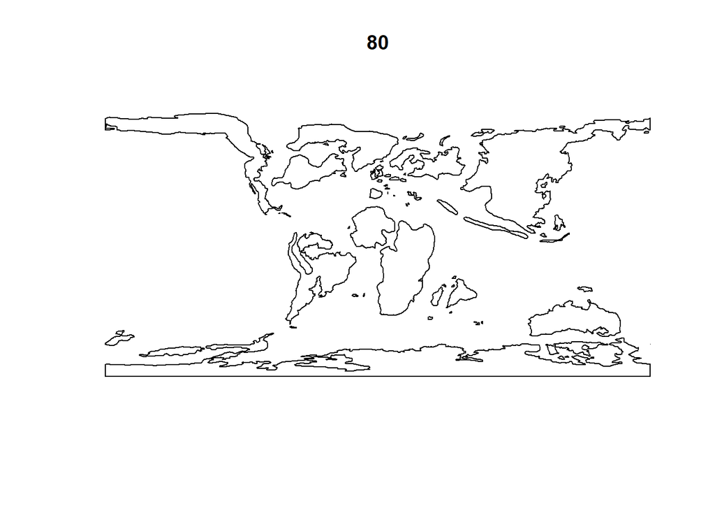

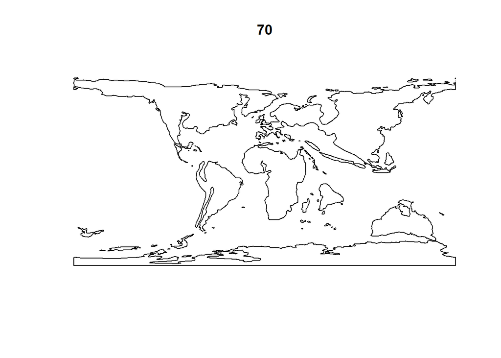

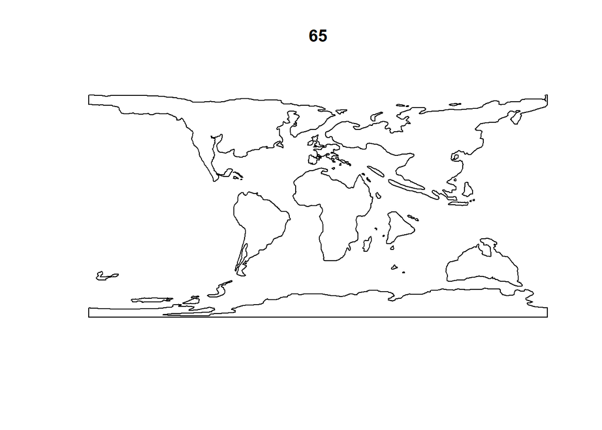

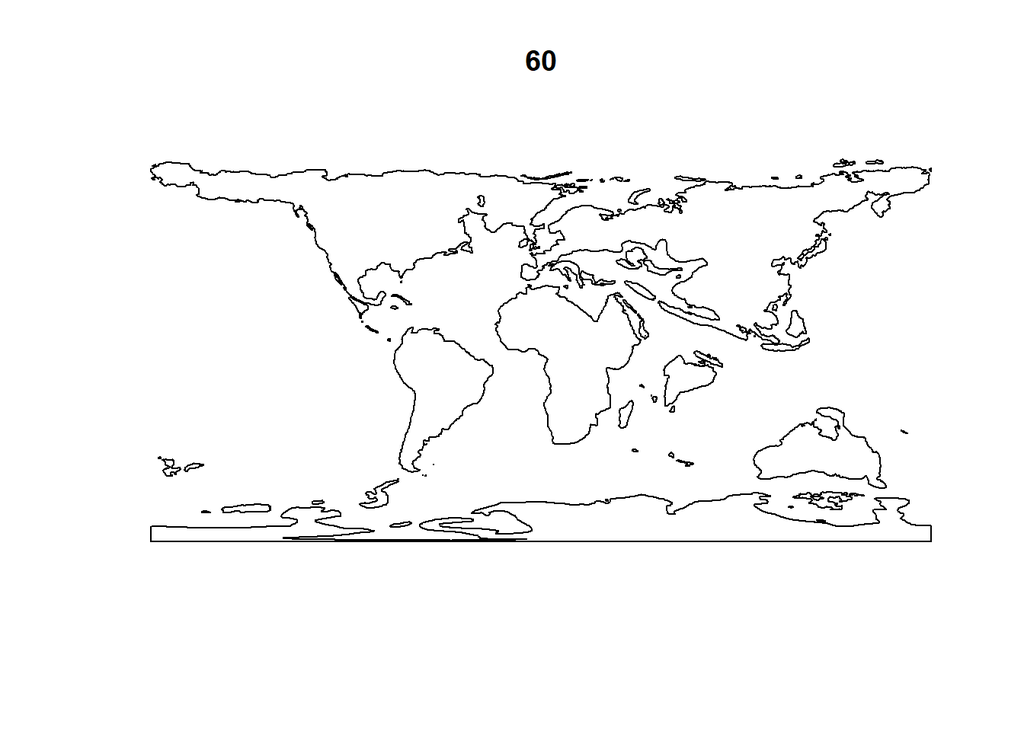

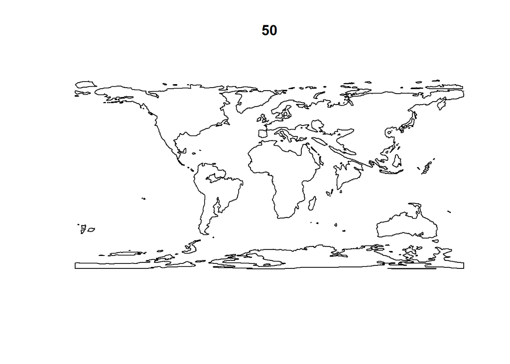

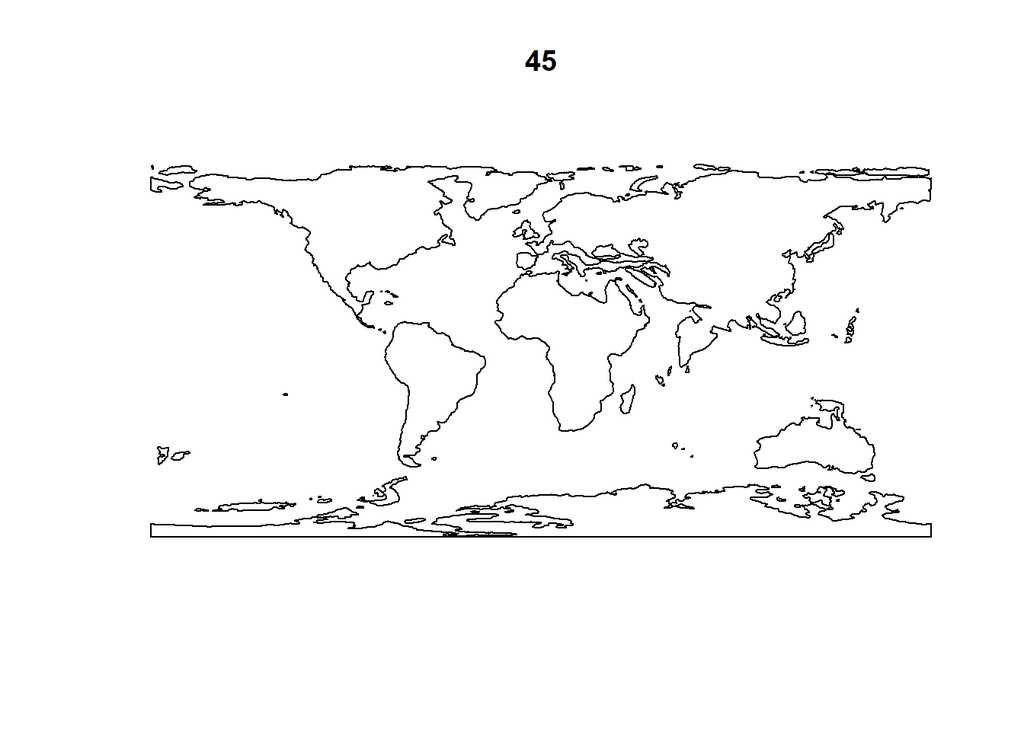

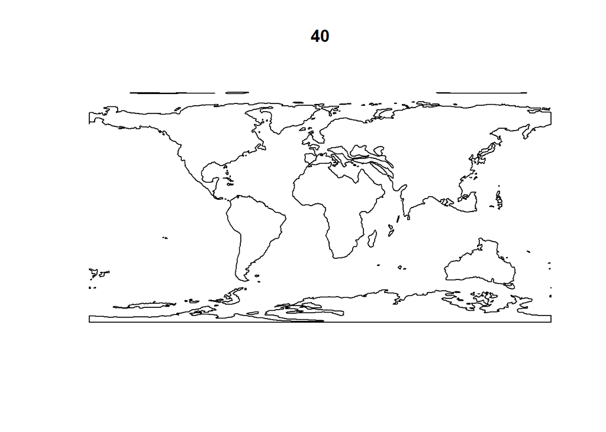

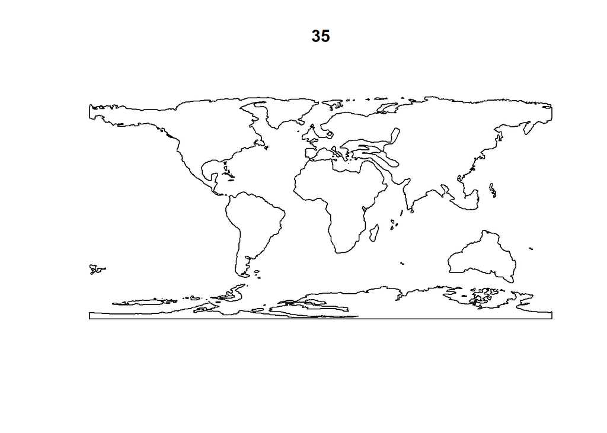

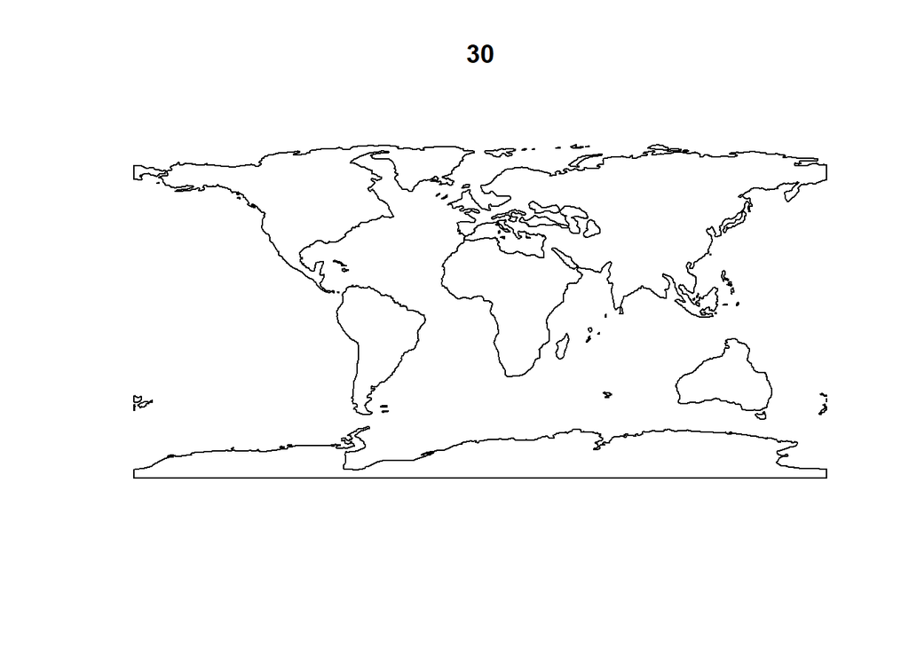

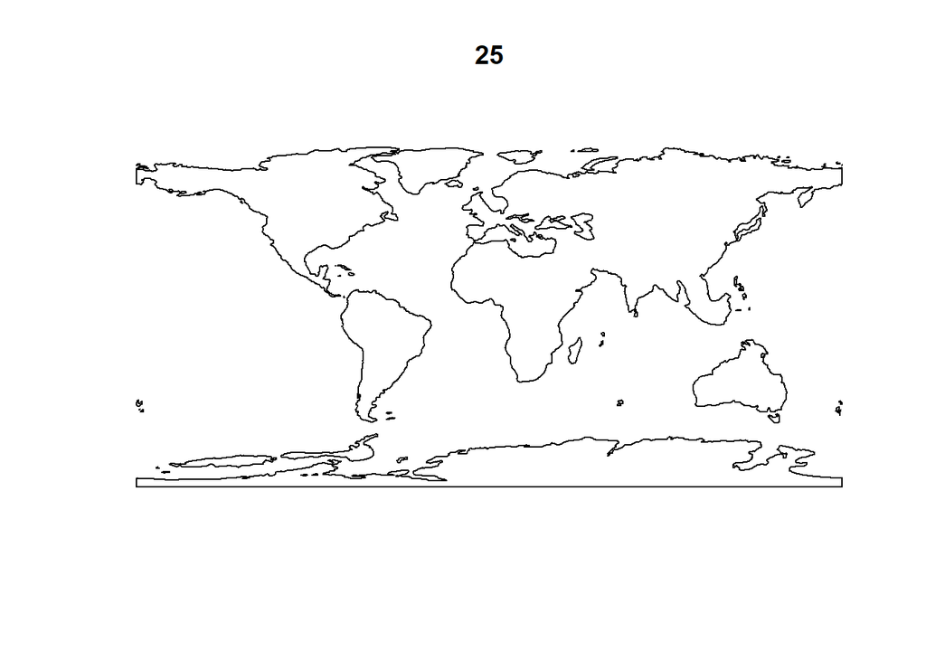

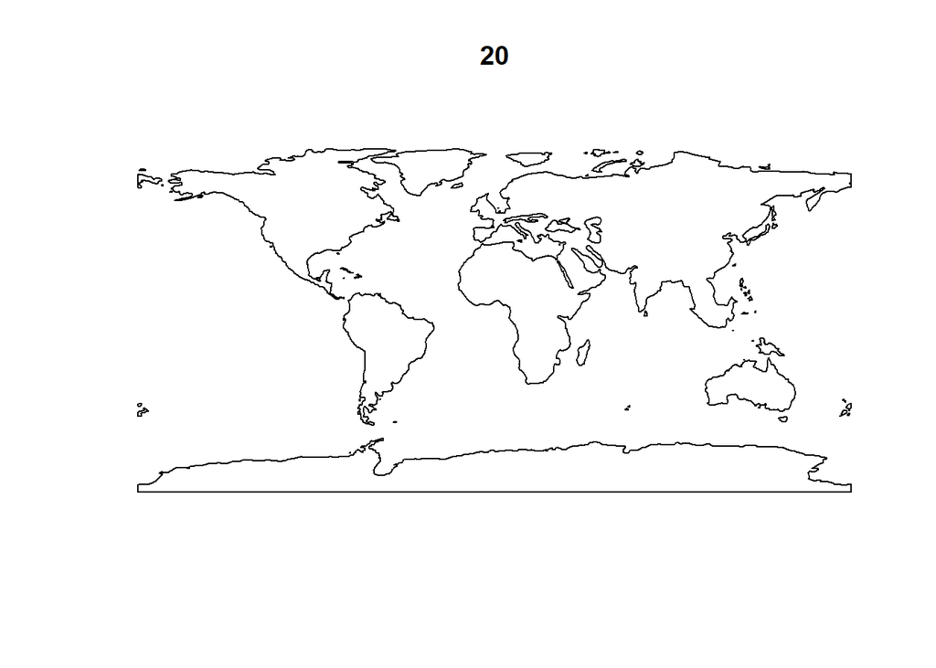

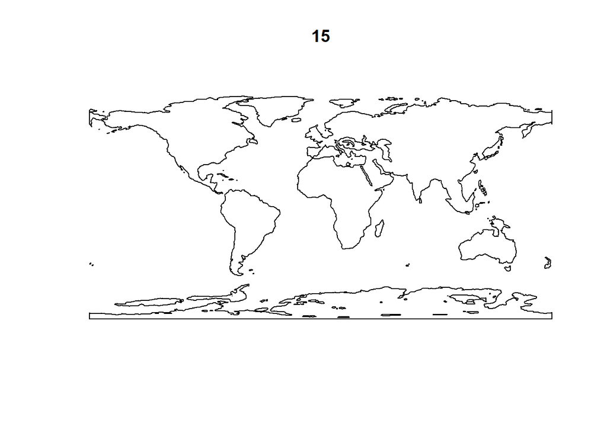

[3 more figures not shown]

```r
ages <- c(
  "80",
  "70",
  "65",
  "60",
  "50",
  "45",
  "40",
  "35",
  "30",
  "25",
  "20",
  "15",
  "10",
  "5",
  "0"
)

# initalize empty list to save the selected time slices
paleo_coasts_list <-
  vector("list", length(ages))

for (i in seq_along(ages)) {
  age <-
    ages[i]

  pc <-
    sf::st_sf(geometry = paleo_coasts[age, "coast"])

  plot(pc, main = age)

  pc["time_slice"] <-
    age
  paleo_coasts_list[[i]] <-
    pc
}
```

### 3. Identify Madagascar and Africa in Paleo reconstructions

This is a bit tideous because I cannot automatically match Africa and Madgaascar to the shapefiles through time. Instead I’m exploding the multiploygons from the shapefiles into single polygons, assing them individual ids, plot each reconstruction colored by polygon id and extract the polygon_ids for Africa and Madagascar. For Africa I can automatize it [WIP]

```r
# Africa automatization:
world <- rnaturalearth::ne_countries(
  scale = "large",
  returnclass = "sf"
)
sf_use_s2(TRUE)
africa_now <- world %>%
  filter(continent == "Africa" & admin != "Madagascar") %>%
  sf::st_make_valid() %>%
  summarise(region = "Africa") %>%
  sf::st_transform(6933) %>%
  sf::st_buffer(100 * 1000) %>%
  sf::st_transform(4326) %>%
  sf::st_make_valid()
```

```r
afr_list <- vector("list", length(paleo_coasts_list))
sf_use_s2(FALSE)
```

```
Spherical geometry (s2) switched off
```

```
although coordinates are longitude/latitude, st_intersection assumes that they
are planar
```

```
although coordinates are longitude/latitude, st_union assumes that they are
planar
```

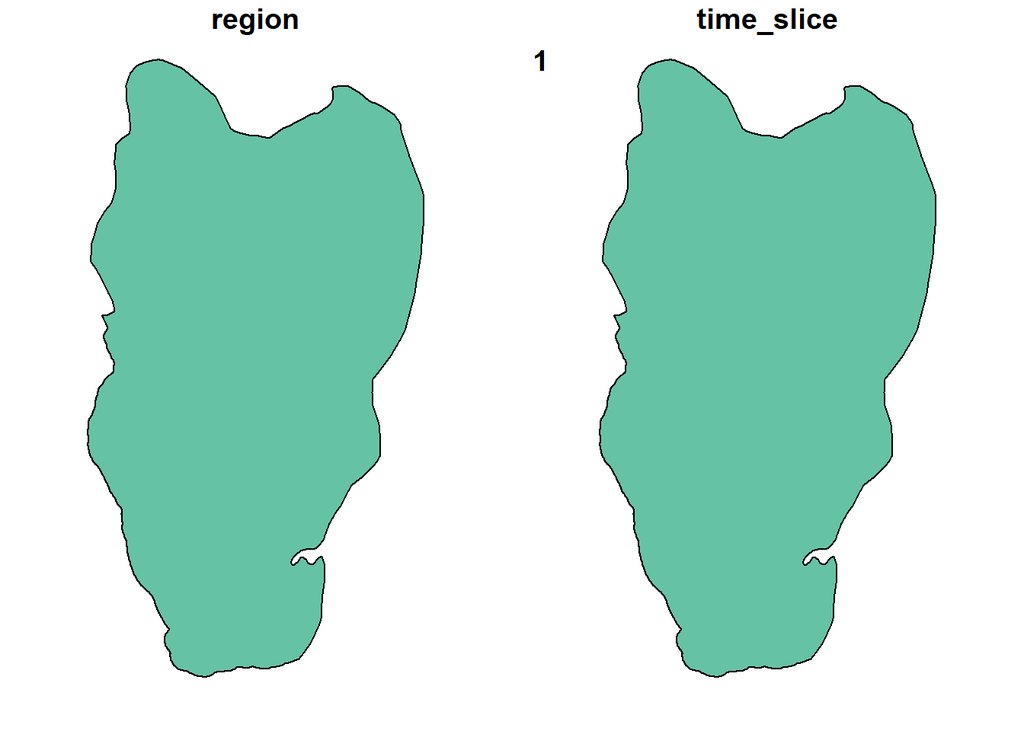

```
although coordinates are longitude/latitude, st_intersection assumes that they
are planar
```

```
although coordinates are longitude/latitude, st_union assumes that they are
planar
```

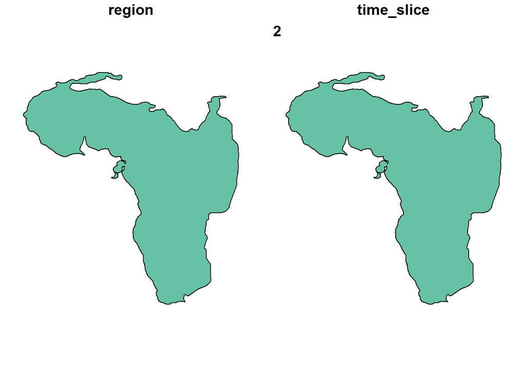

```
although coordinates are longitude/latitude, st_intersection assumes that they
are planar
```

```
although coordinates are longitude/latitude, st_union assumes that they are
planar
```

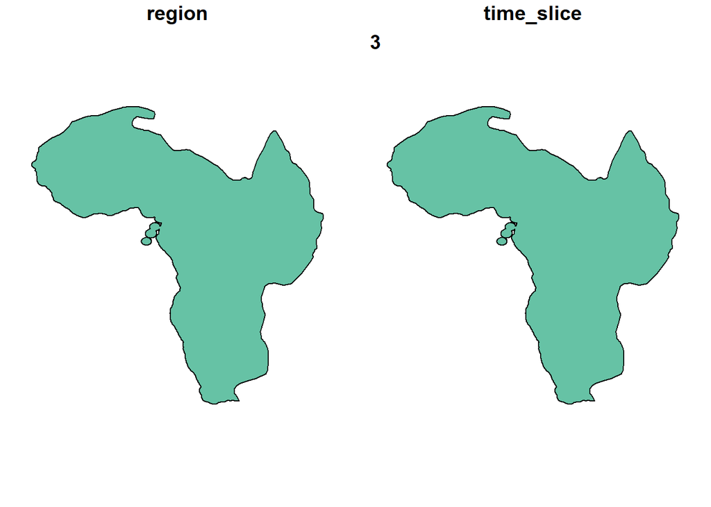

```
although coordinates are longitude/latitude, st_intersection assumes that they
are planar
```

```
although coordinates are longitude/latitude, st_union assumes that they are
planar
```

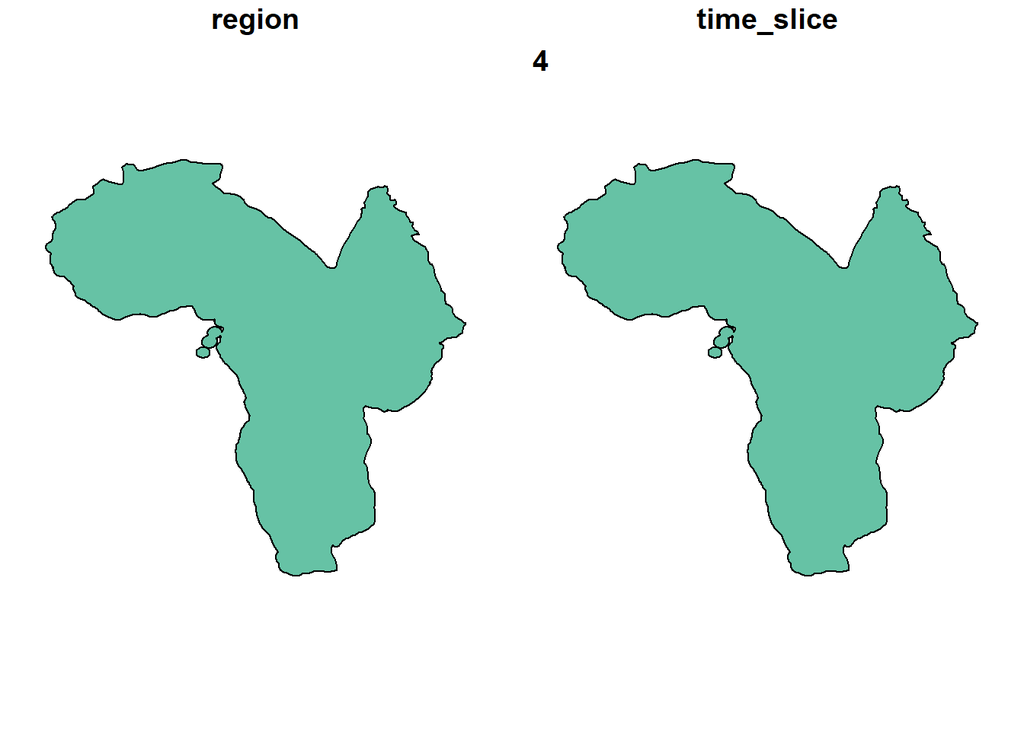

```
although coordinates are longitude/latitude, st_intersection assumes that they
are planar
```

```
although coordinates are longitude/latitude, st_union assumes that they are
planar
```

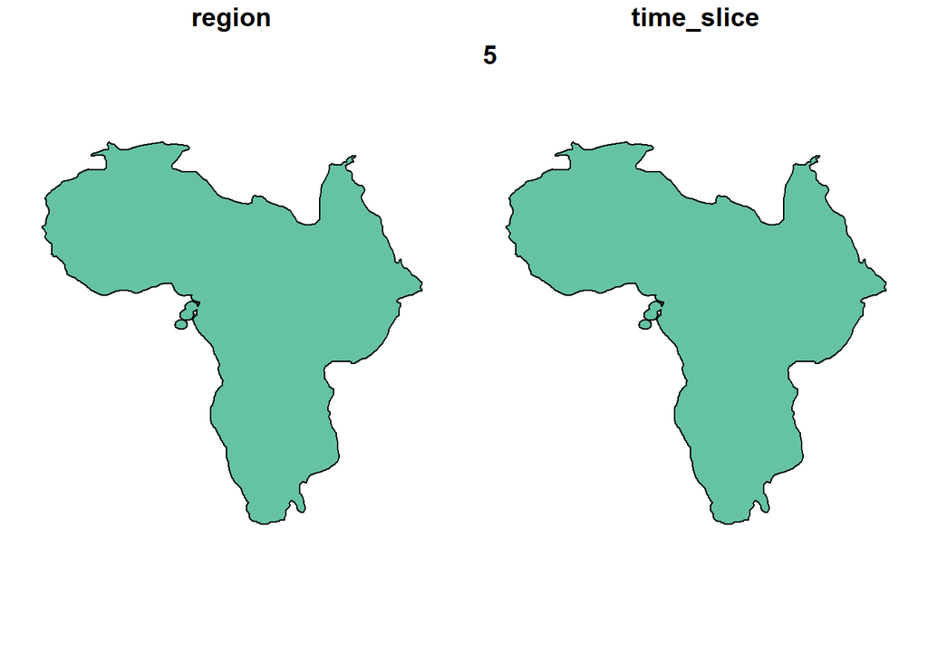

```
although coordinates are longitude/latitude, st_intersection assumes that they
are planar
```

```
although coordinates are longitude/latitude, st_union assumes that they are
planar
```

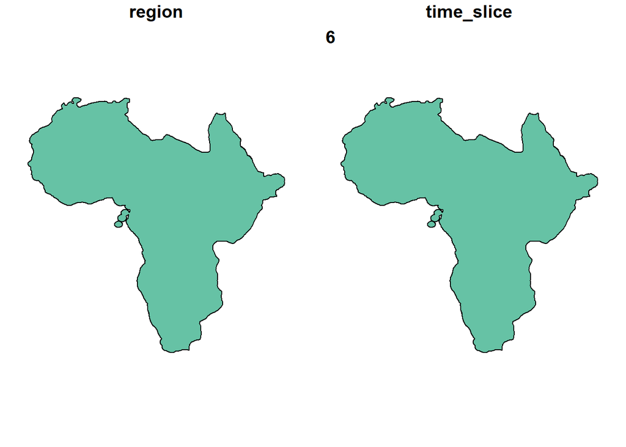

```
although coordinates are longitude/latitude, st_intersection assumes that they
are planar
```

```
although coordinates are longitude/latitude, st_union assumes that they are
planar
```

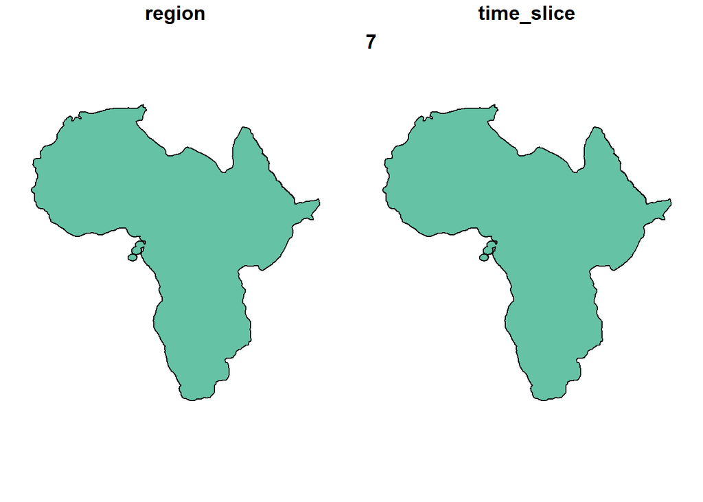

```
although coordinates are longitude/latitude, st_intersection assumes that they
are planar
```

```
although coordinates are longitude/latitude, st_union assumes that they are
planar
```

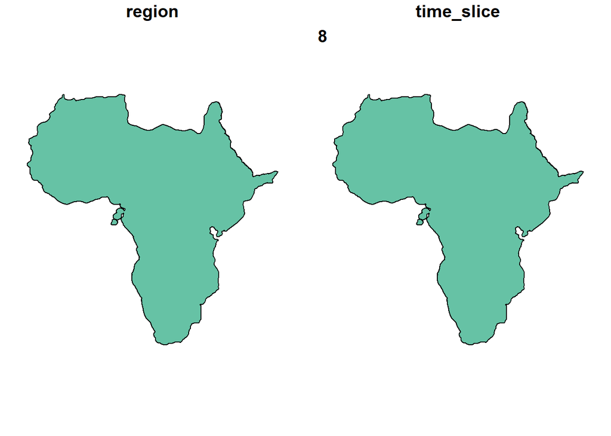

```
although coordinates are longitude/latitude, st_intersection assumes that they
are planar
```

```
although coordinates are longitude/latitude, st_union assumes that they are
planar
```

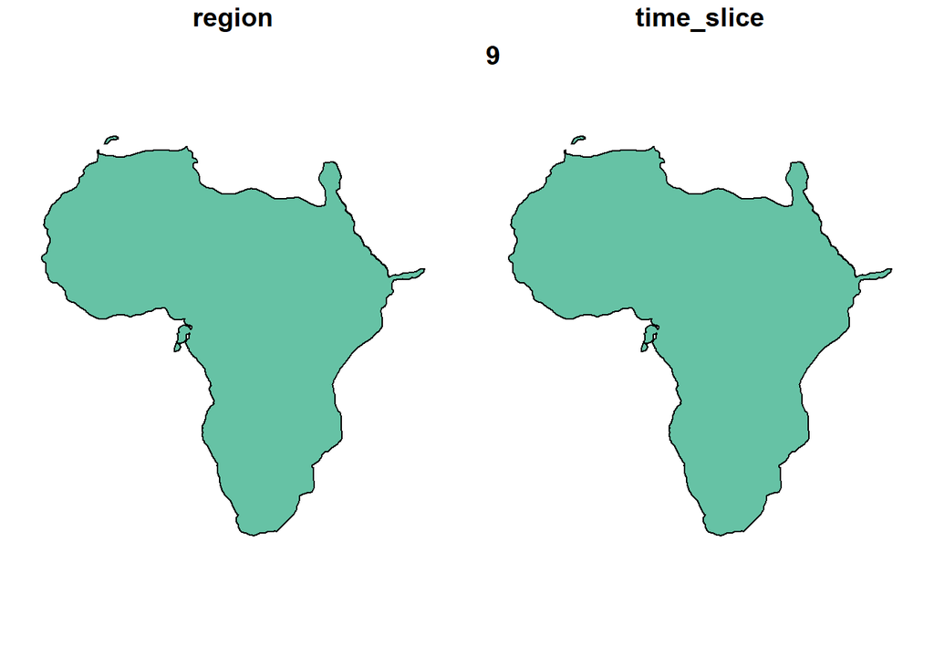

```
although coordinates are longitude/latitude, st_intersection assumes that they
are planar
```

```
although coordinates are longitude/latitude, st_union assumes that they are
planar
```

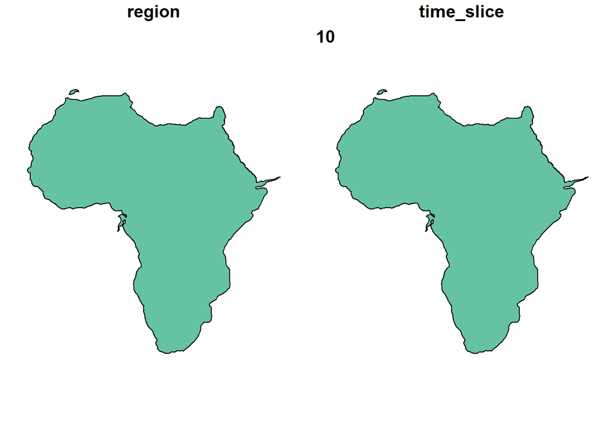

```
although coordinates are longitude/latitude, st_intersection assumes that they
are planar
```

```
although coordinates are longitude/latitude, st_union assumes that they are
planar
```

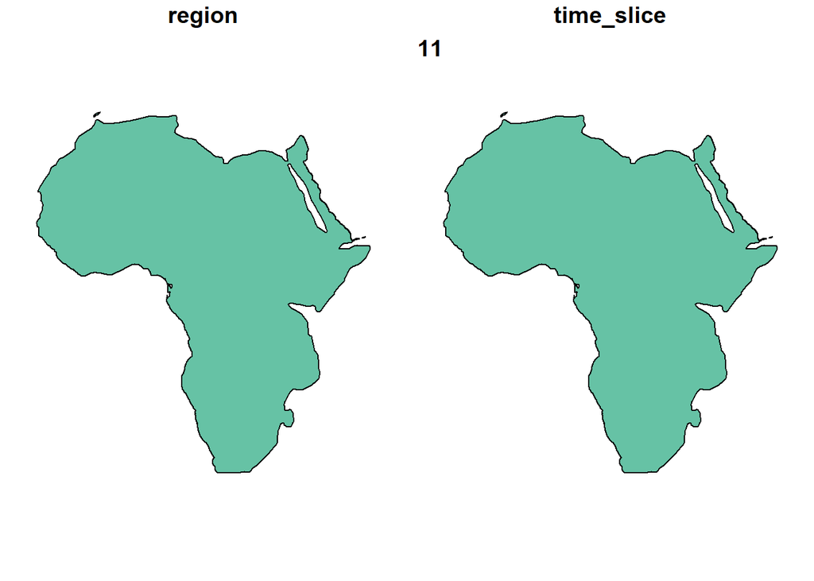

```
although coordinates are longitude/latitude, st_intersection assumes that they
are planar
```

```
although coordinates are longitude/latitude, st_union assumes that they are
planar
```

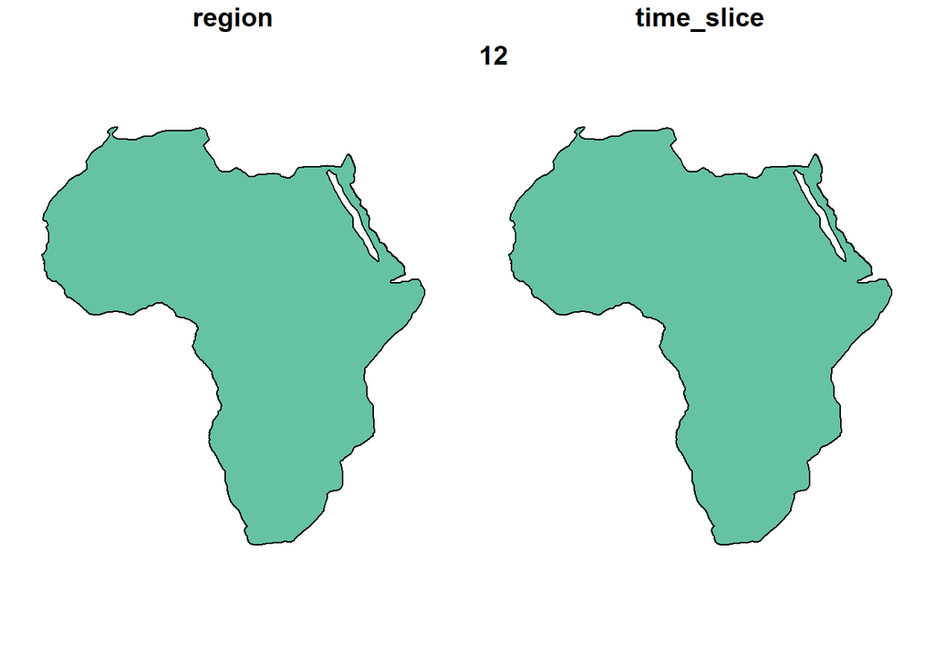

```
although coordinates are longitude/latitude, st_intersection assumes that they
are planar
```

```
although coordinates are longitude/latitude, st_union assumes that they are
planar
```

[3 more figures not shown]

```r
for (i in seq_along(paleo_coasts_list)) {
  africa <-
    paleo_coasts_list[[i]] %>%
    sf::st_cast("POLYGON") %>%
    sf::st_intersection(africa_now) %>%
    mutate(area = as.numeric(sf::st_area(geometry)) / 1000) %>%
    arrange(desc(area)) %>%
    mutate(poly_id = row_number()) %>%
    slice_max(area) %>%
    summarize(region = "Africa", time_slice = unique(time_slice))

  afr_list[[i]] <-
    africa

  plot(africa)
  title(i)
}
```

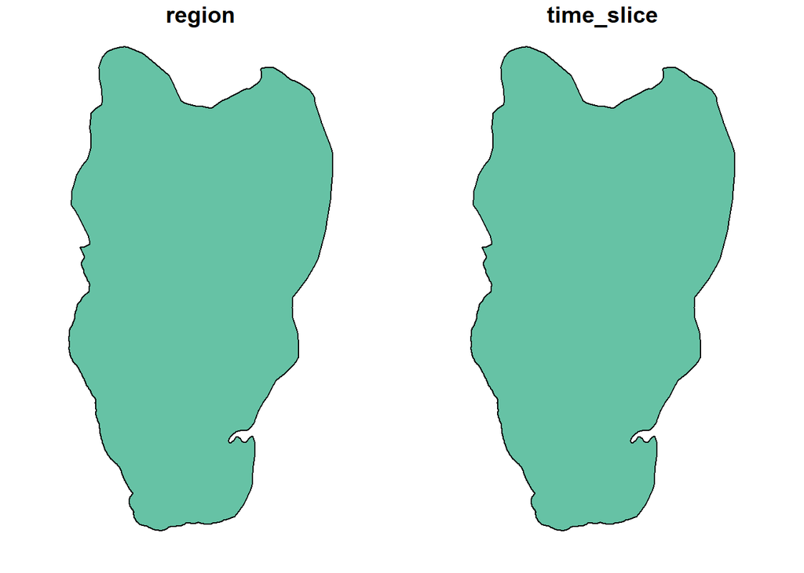

```r
# Fix the first time slice where Africa is separated into two parts
afr_list[[1]] %>% plot()
```

```r
africa <-
  paleo_coasts_list[[1]] %>%
  sf::st_intersection(africa_now) %>%
  sf::st_cast("POLYGON") %>%
  mutate(area = as.numeric(sf::st_area(geometry)) / 1000) %>%
  arrange(desc(area)) %>%
  mutate(poly_id = row_number()) %>%
  slice_head(n = 2) %>%
  summarize(region = "Africa", time_slice = unique(time_slice))
```

```
although coordinates are longitude/latitude, st_intersection assumes that they
are planar
```

```
although coordinates are longitude/latitude, st_union assumes that they are
planar
```

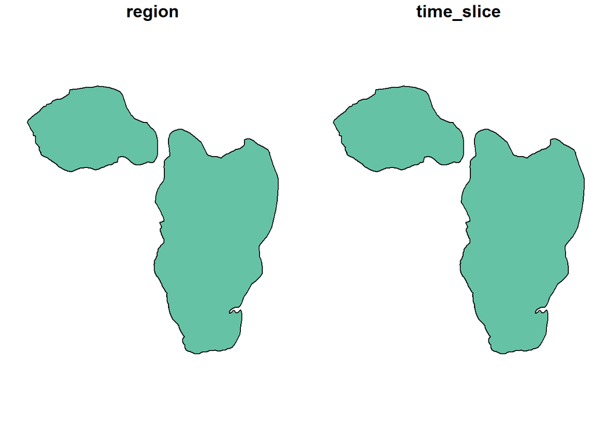

```r
plot(africa)
```

```r
afr_list[[1]] <-
  africa
```

Madagascar:

```r
# Empty vector
mda_list <-
  vector("list", length(paleo_coasts_list))
```

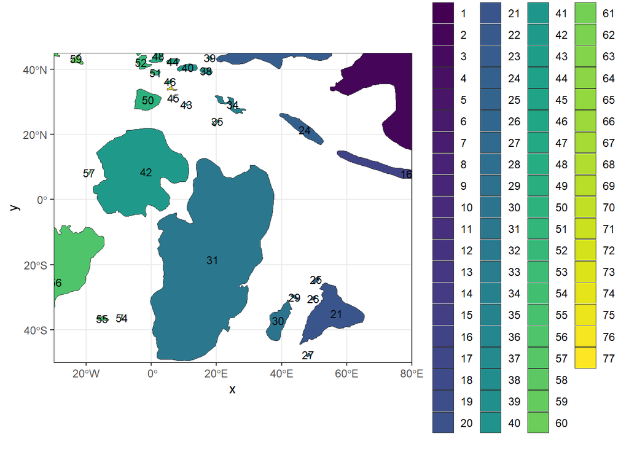

```r
# chose list element
i <- 1

# extract list element
pc <-
  paleo_coasts_list[[i]] %>%
  sf::st_cast("POLYGON") %>%
  mutate(poly_id = row_number())
# plot zoomed map with ids
ggplot(pc) +
  geom_sf(aes(fill = factor(poly_id)), color = "grey20", linewidth = 0.2) +
  geom_sf_text(aes(label = poly_id), size = 3, check_overlap = TRUE) +
  scale_fill_viridis_d(name = "poly_id") +
  coord_sf(
    xlim = c(-30, 80),
    ylim = c(-50, 45),
    expand = FALSE
  ) +
  theme_bw()
```

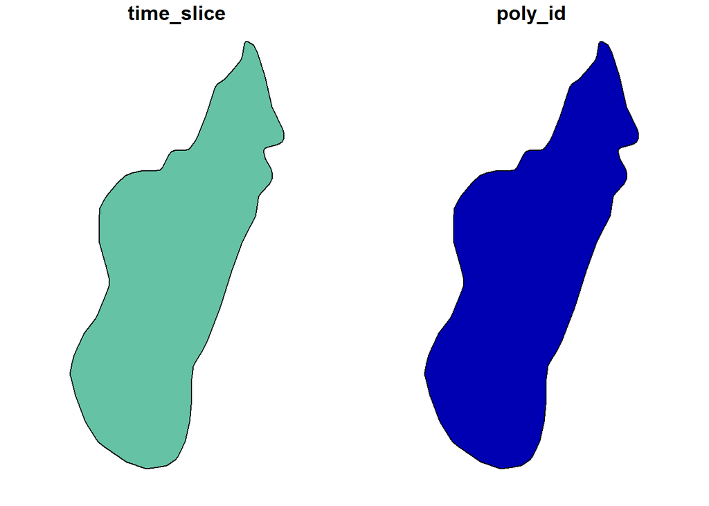

```r
# chose id
id <- 30
# check plot
pc %>%
  filter(poly_id == id) %>%
  plot()
```

```r
# save to list
mda_list[[i]] <-
  pc %>%
  filter(poly_id == id) %>%
  summarize(region = "Madagascar", time_slice = unique(time_slice))
```

```
although coordinates are longitude/latitude, st_union assumes that they are
planar
```

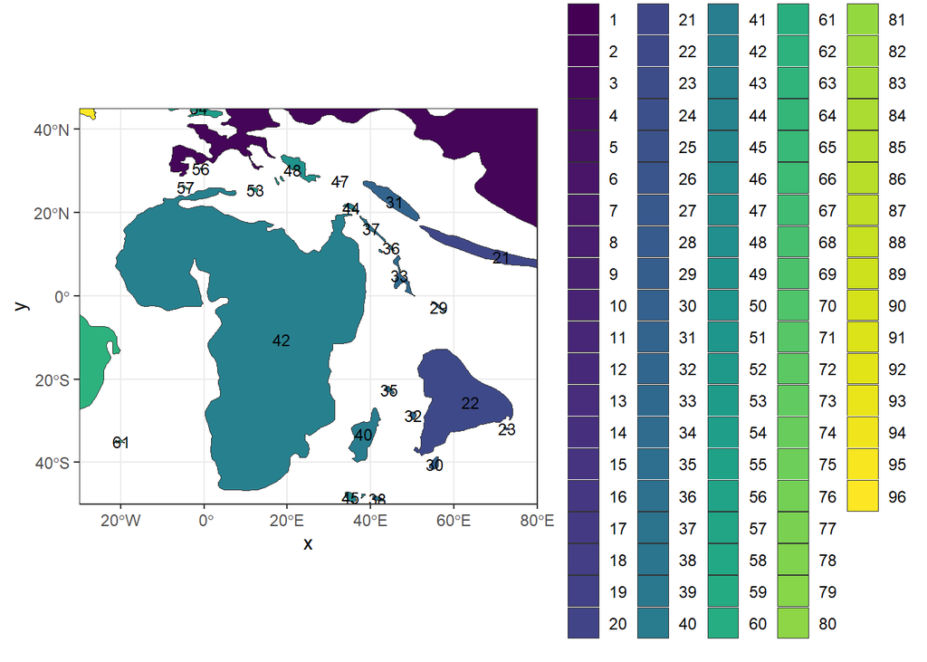

```r
# chose list element
i <- 2

# extract list element
pc <-
  paleo_coasts_list[[i]] %>%
  sf::st_cast("POLYGON") %>%
  mutate(poly_id = row_number())
# plot zoomed map with ids
ggplot(pc) +
  geom_sf(aes(fill = factor(poly_id)), color = "grey20", linewidth = 0.2) +
  geom_sf_text(aes(label = poly_id), size = 3, check_overlap = TRUE) +
  scale_fill_viridis_d(name = "poly_id") +
  coord_sf(
    xlim = c(-30, 80),
    ylim = c(-50, 45),
    expand = FALSE
  ) +
  theme_bw()
```

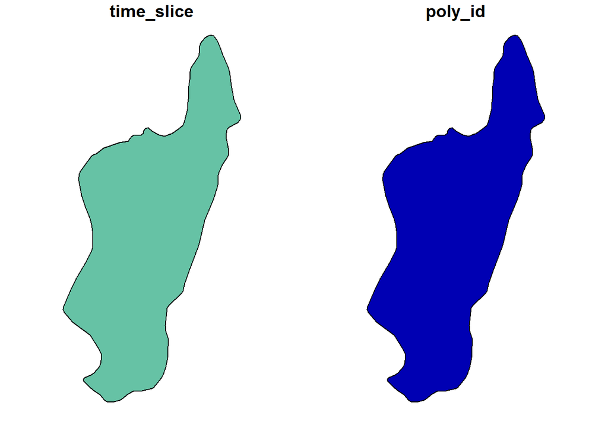

```r
# chose id
id <- 40

# check plot
pc %>%
  filter(poly_id == id) %>%
  plot()
```

```r
# save to list
mda_list[[i]] <-
  pc %>%
  filter(poly_id == id) %>%
  summarize(region = "Madagascar", time_slice = unique(time_slice))
```

```
although coordinates are longitude/latitude, st_union assumes that they are
planar
```